# Project #2: Credit Card Fraud Detection

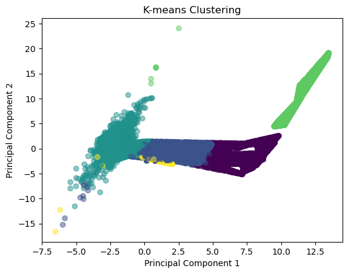

```python
#Non-supervised learning

pca = PCA(n_components=2)
X_pca = pca.fit_transform(X_train_sm)

# K-means
kmeans = KMeans(n_clusters=5, random_state=42)
y_kmeans = kmeans.fit_predict(X_train_sm)

# Visualize the clusters
plt.scatter(X_pca[:, 0], X_pca[:, 1], c=y_kmeans, cmap='viridis', alpha=0.5)
plt.title('K-means Clustering')
plt.xlabel('Principal Component 1')
plt.ylabel('Principal Component 2')
plt.show()
```

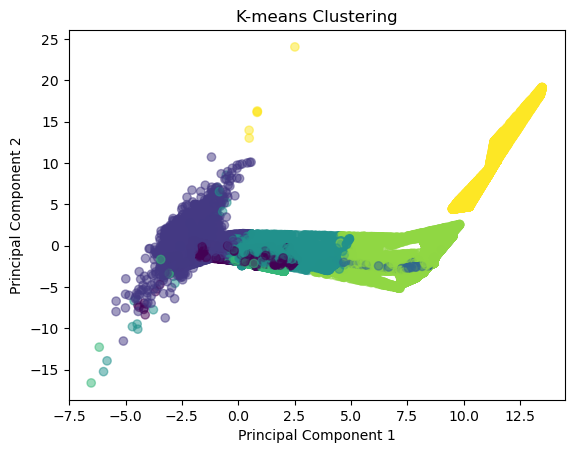

```python
#Non-supervised learning

pca = PCA(n_components=2)
X_pca = pca.fit_transform(X_train_sm)

# K-means
kmeans = KMeans(n_clusters=7, random_state=42)
y_kmeans = kmeans.fit_predict(X_train_sm)

# Visualize the clusters
plt.scatter(X_pca[:, 0], X_pca[:, 1], c=y_kmeans, cmap='viridis', alpha=0.5)
plt.title('K-means Clustering')
plt.xlabel('Principal Component 1')
plt.ylabel('Principal Component 2')
plt.show()
```

Now some supervised models were explored to see which models best predict the fraudulent credit card transactions.

```python
# Applying Random Forest Classifier

from sklearn.model_selection import GridSearchCV, train_test_split
from sklearn.metrics import accuracy_score
from sklearn.model_selection import RandomizedSearchCV


# Define the Random Forest classifier
random_forest = RandomForestClassifier(random_state=42, n_jobs=2)

param_dist = {
    'n_estimators': [5,10,15,20],
    'max_depth': [None, 5, 10],
    'min_samples_split': [2, 4],
    'min_samples_leaf': [1, 2]
}

random_search = RandomizedSearchCV(estimator=random_forest, param_distributions=param_dist, n_iter=10, cv=3, scoring='accuracy', random_state=42, n_jobs=-1)
random_search.fit(X_train_sm, y_train_sm)
```

```
RandomizedSearchCV(cv=3,
                   estimator=RandomForestClassifier(n_jobs=2, random_state=42),
                   n_jobs=-1,
                   param_distributions={'max_depth': [None, 5, 10],
                                        'min_samples_leaf': [1, 2],
                                        'min_samples_split': [2, 4],
                                        'n_estimators': [5, 10, 15, 20]},
                   random_state=42, scoring='accuracy')
```

```python
#Evaluation for Val

print("Best Parameters: ", random_search.best_params_)

best_random_forest = random_search.best_estimator_
y_val_pred = best_random_forest.predict(X_val)

# Calculate validation accuracy
accuracy = accuracy_score(y_val, y_val_pred)
print("Validation Accuracy: {:.2f}%".format(accuracy * 100))

#Evaluate for Test X
y_test_pred = best_random_forest.predict(X_test)

# Calculate test accuracy
test_accuracy = accuracy_score(y_test, y_test_pred)
print("Test Accuracy: {:.2f}%".format(test_accuracy * 100))
```

```
Best Parameters:  {'n_estimators': 5, 'min_samples_split': 4, 'min_samples_leaf': 1, 'max_depth': None}
Validation Accuracy: 91.13%
Test Accuracy: 99.93%
```

```python
# Applying Decision Tree Classifier
decision_tree = DecisionTreeClassifier(random_state = 42)
decision_tree.fit(X_train_sm,y_train_sm)
y_pred_dt = decision_tree.predict(X_test)
```

```python
from sklearn.model_selection import RandomizedSearchCV
from sklearn.tree import DecisionTreeClassifier

# Define the Decision Tree Classifier
decision_tree = DecisionTreeClassifier(random_state=42)

# Define the hyperparameters and their possible values
param_distributions = {
    'criterion': ['gini', 'entropy'],
    'max_depth': [None, 5, 10],
    'min_samples_split': [2, 5, 7],
    'min_samples_leaf': [1, 2, 4]
}

# Use RandomizedSearchCV to find the best hyperparameters
random_search = RandomizedSearchCV(decision_tree, param_distributions, n_iter=10, cv=3, scoring='accuracy', random_state=42)
random_search.fit(X_train_sm, y_train_sm)
```

```
RandomizedSearchCV(cv=3, estimator=DecisionTreeClassifier(random_state=42),
                   param_distributions={'criterion': ['gini', 'entropy'],
                                        'max_depth': [None, 5, 10],
                                        'min_samples_leaf': [1, 2, 4],
                                        'min_samples_split': [2, 5, 7]},
                   random_state=42, scoring='accuracy')
```

```python
# Get the best hyperparameters
best_params = random_search.best_params_
print("Best Hyperparameters:", best_params)

# Train a new Decision Tree model with the best hyperparameters
best_decision_tree = DecisionTreeClassifier(random_state=42, **best_params)
best_decision_tree.fit(X_train_sm, y_train_sm)

y_pred_dt = best_decision_tree.predict(X_test)

y_val_pred_dt = best_decision_tree.predict(X_val)

# Calculate validation and tes accuracy
val_accuracy_dt = accuracy_score(y_val, y_val_pred_dt)
print("Validation Accuracy (Decision Tree): {:.2f}%".format(val_accuracy_dt * 100))
test_accuracy = accuracy_score(y_test, y_pred_dt)
print("Test Accuracy: {:.2f}%".format(test_accuracy * 100))
```

```
Best Hyperparameters: {'min_samples_split': 7, 'min_samples_leaf': 2, 'max_depth': None, 'criterion': 'entropy'}
Validation Accuracy (Decision Tree): 71.65%
Test Accuracy: 99.83%
```

```python
from sklearn.metrics import recall_score

# Evaluate models
def evaluate_model(y_true, y_pred, model_name):
    accuracy = accuracy_score(y_true, y_pred)
    precision = precision_score(y_true, y_pred)
    recall = recall_score(y_true, y_pred)
    f1 = f1_score(y_true, y_pred)

    print(f"Metrics for {model_name}:")
    print(f"Accuracy: {accuracy:.4f}")
    print(f"Precision: {precision:.4f}")
    print(f"Recall: {recall:.4f}")
    print(f"F1 Score: {f1:.4f}")
    print()

evaluate_model(y_test, y_test_pred , "Random Forest")
evaluate_model(y_test, y_pred_dt, "Decision Tree")

print("\nClassification Report RF:\n", classification_report(y_test, y_test_pred))
print("\nClassification Report DT:\n", classification_report(y_test, y_pred_dt))
```

```
Metrics for Random Forest:
Accuracy: 0.9993
Precision: 0.7364
Recall: 0.8051
F1 Score: 0.7692

Metrics for Decision Tree:
Accuracy: 0.9983
Precision: 0.4372
Recall: 0.7966
F1 Score: 0.5646


Classification Report RF:
               precision    recall  f1-score   support

           0       1.00      1.00      1.00     85321
           1       0.74      0.81      0.77       118

    accuracy                           1.00     85439
   macro avg       0.87      0.90      0.88     85439
weighted avg       1.00      1.00      1.00     85439


Classification Report DT:
               precision    recall  f1-score   support

           0       1.00      1.00      1.00     85321
           1       0.44      0.80      0.56       118

    accuracy                           1.00     85439
   macro avg       0.72      0.90      0.78     85439
weighted avg       1.00      1.00      1.00     85439
```

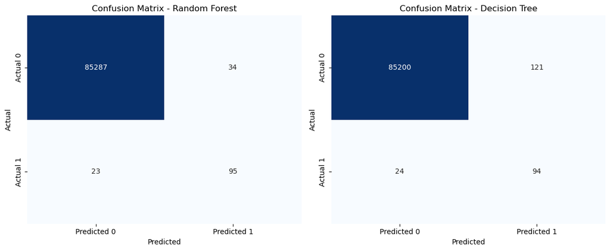

```python
from sklearn.metrics import confusion_matrix
import seaborn as sns
import matplotlib.pyplot as plt

# Function to plot confusion matrix
def plot_confusion_matrix(y_true, y_pred, model_name, ax):
    cm = confusion_matrix(y_true, y_pred)
    sns.heatmap(cm, annot=True, fmt="d", cmap="Blues", cbar=False,
                xticklabels=['Predicted 0', 'Predicted 1'],
                yticklabels=['Actual 0', 'Actual 1'], ax=ax)
    ax.set_title(f'Confusion Matrix - {model_name}')
    ax.set_xlabel('Predicted')
    ax.set_ylabel('Actual')

fig, axes = plt.subplots(1, 2, figsize=(12, 5))

#Plot Confusion Matrix
plot_confusion_matrix(y_test, y_test_pred, "Random Forest", axes[0])
plot_confusion_matrix(y_test, y_pred_dt, "Decision Tree", axes[1])

plt.tight_layout()
plt.show()
```

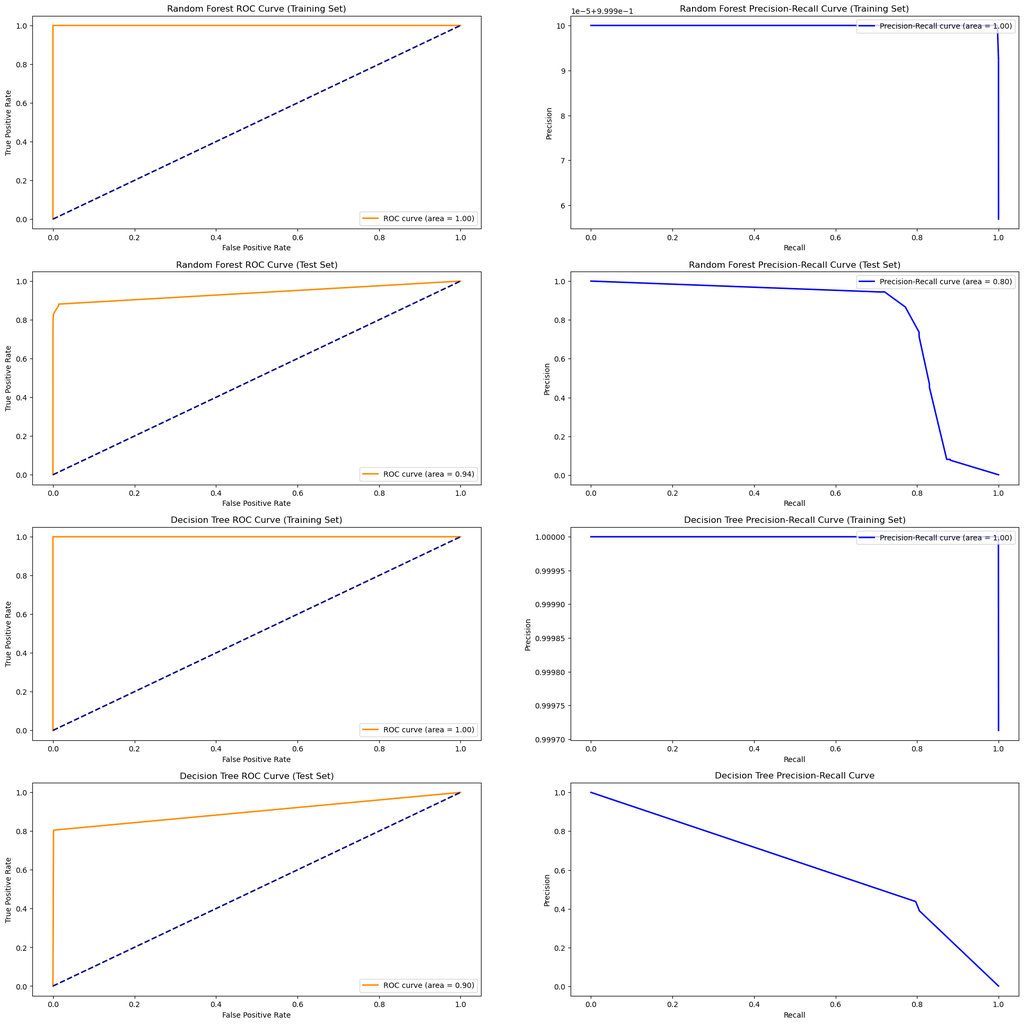

```python
## The ROC and Precision recall curves to see how well the models are doing with hypertuning
from sklearn.metrics import roc_curve
from sklearn.metrics import precision_recall_curve
from sklearn.metrics import auc

# Evaluate on Training Set for Random Forest
y_train_pred_proba_rf = best_random_forest.predict_proba(X_train_sm)[:, 1]
fpr_train_rf, tpr_train_rf, _ = roc_curve(y_train_sm, y_train_pred_proba_rf)
precision_train_rf, recall_train_rf, _ = precision_recall_curve(y_train_sm, y_train_pred_proba_rf)

# Evaluate on Test Set for Random Forest
y_test_pred_proba_rf = best_random_forest.predict_proba(X_test)[:, 1]
fpr_test_rf, tpr_test_rf, _ = roc_curve(y_test, y_test_pred_proba_rf)
precision_test_rf, recall_test_rf, _ = precision_recall_curve(y_test, y_test_pred_proba_rf)

# Evaluate on Training Set for Decision Tree
y_train_pred_proba_dt = best_decision_tree.predict_proba(X_train_sm)[:, 1]
fpr_train_dt, tpr_train_dt, _ = roc_curve(y_train_sm, y_train_pred_proba_dt)
precision_train_dt, recall_train_dt, _ = precision_recall_curve(y_train_sm, y_train_pred_proba_dt)

# Evaluate on Test Set for Decision Tree
y_test_pred_proba_dt = best_decision_tree.predict_proba(X_test)[:, 1]
fpr_test_dt, tpr_test_dt, _ = roc_curve(y_test, y_test_pred_proba_dt)
precision_test_dt, recall_test_dt, _ = precision_recall_curve(y_test, y_test_pred_proba_dt)

plt.figure(figsize=(24, 24))

# Random Forest on Training Set
plt.subplot(4, 2, 1)
plt.plot(fpr_train_rf, tpr_train_rf, color='darkorange', lw=2, label='ROC curve (area = {:.2f})'.format(auc(fpr_train_rf, tpr_train_rf)))
plt.plot([0, 1], [0, 1], color='navy', lw=2, linestyle='--')
plt.xlabel('False Positive Rate')
plt.ylabel('True Positive Rate')
plt.title('Random Forest ROC Curve (Training Set)')
plt.legend(loc='lower right')

plt.subplot(4, 2, 2)
plt.plot(recall_train_rf, precision_train_rf, color='blue', lw=2, label='Precision-Recall curve (area = {:.2f})'.format(auc(recall_train_rf, precision_train_rf)))
plt.xlabel('Recall')
plt.ylabel('Precision')
plt.title('Random Forest Precision-Recall Curve (Training Set)')
plt.legend(loc='upper right')

#  Random Forest on Test Set
plt.subplot(4, 2, 3)
plt.plot(fpr_test_rf, tpr_test_rf, color='darkorange', lw=2, label='ROC curve (area = {:.2f})'.format(auc(fpr_test_rf, tpr_test_rf)))
plt.plot([0, 1], [0, 1], color='navy', lw=2, linestyle='--')
plt.xlabel('False Positive Rate')
plt.ylabel('True Positive Rate')
plt.title('Random Forest ROC Curve (Test Set)')
plt.legend(loc='lower right')

plt.subplot(4, 2, 4)
plt.plot(recall_test_rf, precision_test_rf, color='blue', lw=2, label='Precision-Recall curve (area = {:.2f})'.format(auc(recall_test_rf, precision_test_rf)))
plt.xlabel('Recall')
plt.ylabel('Precision')
plt.title('Random Forest Precision-Recall Curve (Test Set)')
plt.legend(loc='upper right')

# Decision Tree on Training Set
plt.subplot(4, 2, 5)
plt.plot(fpr_train_dt, tpr_train_dt, color='darkorange', lw=2, label='ROC curve (area = {:.2f})'.format(auc(fpr_train_dt, tpr_train_dt)))
plt.plot([0, 1], [0, 1], color='navy', lw=2, linestyle='--')
plt.xlabel('False Positive Rate')
plt.ylabel('True Positive Rate')
plt.title('Decision Tree ROC Curve (Training Set)')
plt.legend(loc='lower right')

plt.subplot(4, 2, 6)
plt.plot(recall_train_dt, precision_train_dt, color='blue', lw=2, label='Precision-Recall curve (area = {:.2f})'.format(auc(recall_train_dt, precision_train_dt)))
plt.xlabel('Recall')
plt.ylabel('Precision')
plt.title('Decision Tree Precision-Recall Curve (Training Set)')
plt.legend(loc='upper right')

# Decision Tree on Test Set
plt.subplot(4, 2, 7)
plt.plot(fpr_test_dt, tpr_test_dt, color='darkorange', lw=2, label='ROC curve (area = {:.2f})'.format(auc(fpr_test_dt, tpr_test_dt)))
plt.plot([0, 1], [0, 1], color='navy', lw=2, linestyle='--')
plt.xlabel('False Positive Rate')
plt.ylabel('True Positive Rate')
plt.title('Decision Tree ROC Curve (Test Set)')
plt.legend(loc='lower right')

plt.subplot(4, 2, 8)
plt.plot(recall_test_dt, precision_test_dt, color='blue', lw=2, label='Precision-Recall curve (area = {:.2f})'.format(auc(recall_test_dt, precision_test_dt)))
plt.xlabel('Recall')
plt.ylabel('Precision')
plt.title('Decision Tree Precision-Recall Curve')
```

Now a neural net was used to explore the data first with basic layers and those layers were later further enchanced and run to see if there are potential improvments. The two neural nets were also evaluted by using confusion matrix and roc, precision recell curves. The loss of function and accuracy over time is also evaluated to understand the model better.

```python
#Building a neural network

from tensorflow.keras import Sequential, layers, metrics, optimizers, callbacks
from tensorflow import keras
model = keras.Sequential([
    keras.layers.Dense(256, activation='relu', input_shape=(X_train_sm.shape[-1],)),
    keras.layers.BatchNormalization(),
    keras.layers.Dropout(0.3),
    keras.layers.Dense(256, activation='relu'),
    keras.layers.BatchNormalization(),
    keras.layers.Dropout(0.3),
    keras.layers.Dense(256, activation='relu'),
    keras.layers.BatchNormalization(),
    keras.layers.Dropout(0.3),
    keras.layers.Dense(1, activation='sigmoid'),
])

model.compile(optimizer=keras.optimizers.Adam(1e-4), loss='binary_crossentropy', metrics=['accuracy'])
model.summary()

# Train  model
history0 = model.fit(X_train_sm, y_train_sm, epochs=20, batch_size=512, validation_data=(X_val_scaled, y_val))

# Evaluate model
y_pred = (model.predict(X_test) > 0.5).astype("int32")
```

```
Model: "sequential"
_________________________________________________________________
 Layer (type)                Output Shape              Param #
=================================================================
 dense (Dense)               (None, 256)               7936

 batch_normalization (Batch  (None, 256)               1024
 Normalization)

 dropout (Dropout)           (None, 256)               0

 dense_1 (Dense)             (None, 256)               65792

 batch_normalization_1 (Bat  (None, 256)               1024
 chNormalization)

 dropout_1 (Dropout)         (None, 256)               0

 dense_2 (Dense)             (None, 256)               65792

 batch_normalization_2 (Bat  (None, 256)               1024
 chNormalization)

 dropout_2 (Dropout)         (None, 256)               0

 dense_3 (Dense)             (None, 1)                 257

=================================================================
Total params: 142849 (558.00 KB)
Trainable params: 141313 (552.00 KB)
Non-trainable params: 1536 (6.00 KB)
_________________________________________________________________
```

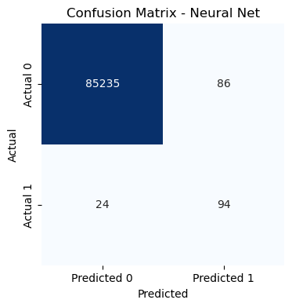

```
Classification Report:
               precision    recall  f1-score   support

           0       1.00      1.00      1.00     85321
           1       0.52      0.80      0.63       118

    accuracy                           1.00     85439
   macro avg       0.76      0.90      0.82     85439
weighted avg       1.00      1.00      1.00     85439
```

```python
def plot_confusion_matrix(y_true, y_pred, model_name):
    cm = confusion_matrix(y_true, y_pred)
    plt.figure(figsize=(4, 4))
    sns.heatmap(cm, annot=True, fmt="d", cmap="Blues", cbar=False,
                xticklabels=['Predicted 0', 'Predicted 1'],
                yticklabels=['Actual 0', 'Actual 1'])
    plt.title(f'Confusion Matrix - {model_name}')
    plt.xlabel('Predicted')
    plt.ylabel('Actual')
    plt.show()

# Plot confusion matrix + classification report
plot_confusion_matrix(y_test, y_pred , "Neural Net")
print("\nClassification Report:\n", classification_report(y_test, y_pred))
```

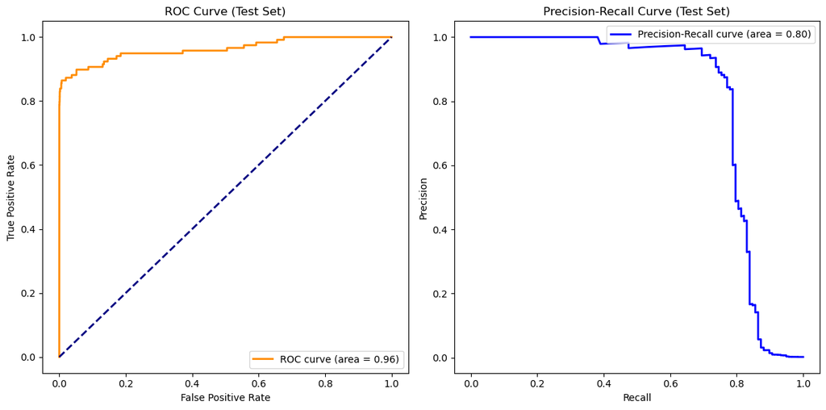

```python
from sklearn.metrics import roc_curve, auc, precision_recall_curve
import matplotlib.pyplot as plt
from sklearn.metrics import confusion_matrix, classification_report

# ROC Curve and Precision-Recall Curve for Test Set
y_pred_proba = model.predict(X_test)
fpr, tpr, _ = roc_curve(y_test, y_pred_proba)
precision, recall, _ = precision_recall_curve(y_test, y_pred_proba)

plt.figure(figsize=(12, 6))

# ROC Curve
plt.subplot(1, 2, 1)
plt.plot(fpr, tpr, color='darkorange', lw=2, label='ROC curve (area = {:.2f})'.format(auc(fpr, tpr)))
plt.plot([0, 1], [0, 1], color='navy', lw=2, linestyle='--')
plt.xlabel('False Positive Rate')
plt.ylabel('True Positive Rate')
plt.title('ROC Curve (Test Set)')
plt.legend(loc='lower right')

# Precision-Recall Curve
plt.subplot(1, 2, 2)
plt.plot(recall, precision, color='blue', lw=2, label='Precision-Recall curve (area = {:.2f})'.format(auc(recall, precision)))
plt.xlabel('Recall')
plt.ylabel('Precision')
plt.title('Precision-Recall Curve (Test Set)')
plt.legend(loc='upper right')

plt.tight_layout()
plt.show()
```

```
Test Loss: 0.008876419626176357
Test Accuracy: 0.9990285634994507
```

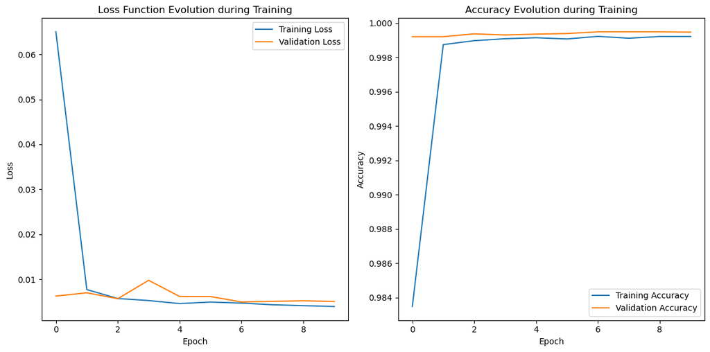

```python
r = model.fit(X_train, y_train, epochs=10, validation_data=(X_val, y_val))

test_loss, test_accuracy = model.evaluate(X_test, y_test)

print(f'Test Loss: {test_loss}')
print(f'Test Accuracy: {test_accuracy}')

plt.figure(figsize=(12, 6))

plt.subplot(1, 2, 1)
plt.plot(r.history['loss'], label='Training Loss')
plt.plot(r.history['val_loss'], label='Validation Loss')
plt.title('Loss Function Evolution during Training')
plt.xlabel('Epoch')
plt.ylabel('Loss')
plt.legend()

plt.subplot(1, 2, 2)
plt.plot(r.history['accuracy'], label='Training Accuracy')
plt.plot(r.history['val_accuracy'], label='Validation Accuracy')
plt.title('Accuracy Evolution during Training')
plt.xlabel('Epoch')
plt.ylabel('Accuracy')
plt.legend()

plt.tight_layout()
plt.show()
```

```python
from tensorflow.keras import Sequential, layers, metrics, optimizers, callbacks
from tensorflow import keras

model = keras.Sequential([
    keras.layers.Dense(512, activation='relu', input_shape=(X_train_sm.shape[-1],)),
    keras.layers.BatchNormalization(),
    keras.layers.Dropout(0.5),

    keras.layers.Dense(512, activation='relu'),
    keras.layers.BatchNormalization(),
    keras.layers.Dropout(0.5),

    keras.layers.Dense(256, activation='relu'),
    keras.layers.BatchNormalization(),
    keras.layers.Dropout(0.3),

    keras.layers.Dense(256, activation='relu'),
    keras.layers.BatchNormalization(),
    keras.layers.Dropout(0.3),

    keras.layers.Dense(128, activation='relu'),
    keras.layers.BatchNormalization(),
    keras.layers.Dropout(0.3),

    keras.layers.Dense(128, activation='relu'),
    keras.layers.BatchNormalization(),
    keras.layers.Dropout(0.3),

    keras.layers.Dense(1, activation='sigmoid'),
])

model.compile(optimizer=keras.optimizers.Adam(1e-4), loss='binary_crossentropy', metrics=['accuracy'])
model.summary()

# Train model
history1 = model.fit(X_train_sm, y_train_sm, epochs=30, batch_size=512, validation_data=(X_val_scaled, y_val))

# Evaluate model
y_pred = (model.predict(X_test) > 0.5).astype("int32")
```

```
Model: "sequential_1"
_________________________________________________________________
 Layer (type)                Output Shape              Param #
=================================================================
 dense_4 (Dense)             (None, 512)               15872

 batch_normalization_3 (Bat  (None, 512)               2048
 chNormalization)

 dropout_3 (Dropout)         (None, 512)               0

 dense_5 (Dense)             (None, 512)               262656

 batch_normalization_4 (Bat  (None, 512)               2048
 chNormalization)

 dropout_4 (Dropout)         (None, 512)               0

 dense_6 (Dense)             (None, 256)               131328

 batch_normalization_5 (Bat  (None, 256)               1024
 chNormalization)

 dropout_5 (Dropout)         (None, 256)               0

 dense_7 (Dense)             (None, 256)               65792

 batch_normalization_6 (Bat  (None, 256)               1024
 chNormalization)

 dropout_6 (Dropout)         (None, 256)               0

 dense_8 (Dense)             (None, 128)               32896

 batch_normalization_7 (Bat  (None, 128)               512
 chNormalization)

 dropout_7 (Dropout)         (None, 128)               0

 dense_9 (Dense)             (None, 128)               16512

 batch_normalization_8 (Bat  (None, 128)               512
 chNormalization)

 dropout_8 (Dropout)         (None, 128)               0

 dense_10 (Dense)            (None, 1)                 129

=================================================================
Total params: 532353 (2.03 MB)
Trainable params: 528769 (2.02 MB)
Non-trainable params: 3584 (14.00 KB)
_________________________________________________________________
```